# HW_LiveSeesion4

Manisha Pendekar

February 7, 2018

# 1. Get the eighteenth dataset from FiveThirtyEight GitHub Data

1. Install and load “FiveThirtyEight” package in R

```r
#install.packages("fivethirtyeight")
library(fivethirtyeight)
```

2. Assign the eighteenth dataset to a dataframe object called “df” in R

```r
listofDs <- data(package = "fivethirtyeight")
items <- listofDs$results[, "Item"]
eighteenth <- items[18]
eighteenth
```

```
## [1] "college_recent_grads"
```

```r
df <- college_recent_grads
#vignette("fivethirtyeight", package = "fivethirtyeight")
```

3. Here is the URL “http://fivethirtyeight.com/features/the-economic-guide-to-picking-a-college-major/” from command “vignette(”fivethirtyeight“, package =”fivethirtyeight“)”

```r
#vignette("fivethirtyeight", package = "fivethirtyeight")
```

4. Print the dimensions of the dataset contained in the “df” object
- Count of Rows and Columns the college_recent_grads dataset

```
## [1] 173  21
```

# 2. Data Summary of college_recent_grads

1. Write an R command that gives you the column names of the data frame. Right after that, write one that counts the number of columns but not rows. Hint: The number should match one of your numbers in Question 1d for dimensions.

```r
# names of the columns in college_recent_grads dataset
names(df)
```

```
##  [1] "rank"                        "major_code"
##  [3] "major"                       "major_category"
##  [5] "total"                       "sample_size"
##  [7] "men"                         "women"
##  [9] "sharewomen"                  "employed"
## [11] "employed_fulltime"           "employed_parttime"
## [13] "employed_fulltime_yearround" "unemployed"
## [15] "unemployment_rate"           "p25th"
## [17] "median"                      "p75th"
## [19] "college_jobs"                "non_college_jobs"
## [21] "low_wage_jobs"
```

```r
# count of columns in college_recent_grads dataset
ncol(df)
```

```
## [1] 21
```

2. Generate a count of each unique major_category in the data frame. I recommend using libraries to help. I have demonstrated one briefly in live-session. To be clear, this should look like a matrix or data frame containing the major_category and the frequency it occurs in the dataset. Assign it to major_count.

```r
# install dplyr library to get Tally funtion
#install.packages("dplyr")
library(dplyr)
major_count <- tally(group_by(df, major_category))
major_count
```

```
## # A tibble: 16 x 2
##    major_category                          n
##    <chr>                               <int>
##  1 Agriculture & Natural Resources        10
##  2 Arts                                    8
##  3 Biology & Life Science                 14
##  4 Business                               13
##  5 Communications & Journalism             4
##  6 Computers & Mathematics                11
##  7 Education                              16
##  8 Engineering                            29
##  9 Health                                 12
## 10 Humanities & Liberal Arts              15
## 11 Industrial Arts & Consumer Services     7
## 12 Interdisciplinary                       1
## 13 Law & Public Policy                     5
## 14 Physical Sciences                      10
## 15 Psychology & Social Work                9
## 16 Social Science                          9
```

3. To make things easier to read, put par(las=2) before your plot to make the text perpendicular to the axis. Make a barplot of major_count. Make sure to label the title with something informative (check the vignette if you need), label the x and y axis, and make it any color other than grey. Assign the major_category labels to their respective bar. Flip the barplot horizontally so that bars extend to the right, not upward. All of these options can be done in a single pass of barplot().

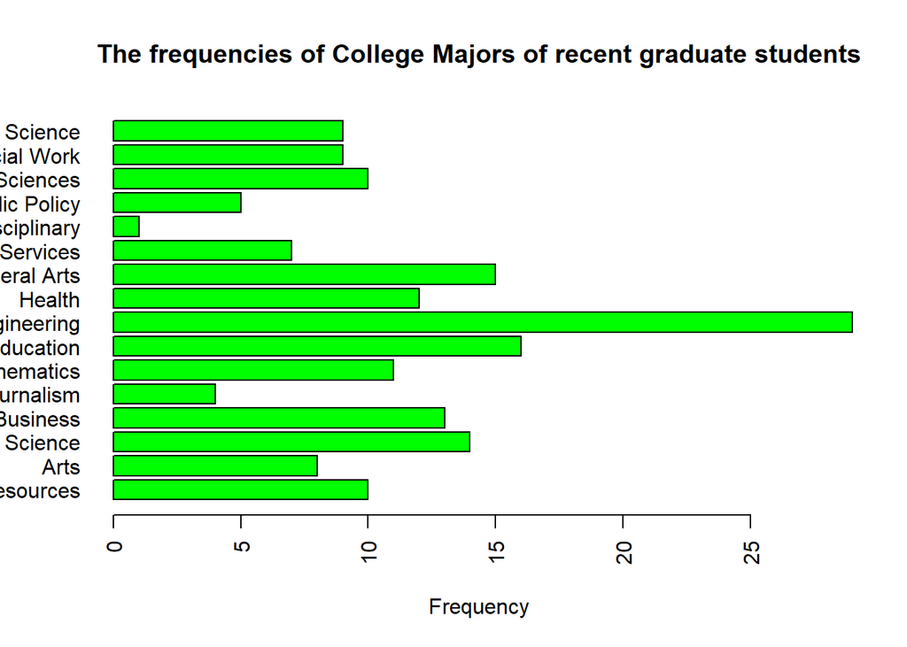

```r
# Barplot of Major categories
par(las=2)
barplot(height = major_count$n, names.arg = major_count$major_category, xlab = "Frequency", horiz = TRUE, col = "green", main = "The frequencies of College Majors of recent graduate students")
```

4. Write the fivethirtyeight data to a csv file. Make sure that it does not have row labels.

```r
# Write a CSV file containing college_recent_grads dataset
write.csv(df, file = "C:\\Manisha\\DDS\\Week4RecentGrads.csv", row.names = FALSE)
#Post GitHub link to homework folder
```

# 3. My GitHub Account Folder link

https://github.com/mapednek/SMU_DDS_Homework/tree/master/HW4